# Bootstrap and Bagging

Time Series

Bootstrap and Bagging Method for Time Series Data

Yeongeun Jeon , Jung In Seo  
06-01-2020

- Data 출처 : [Data Mining for Business Analytics](https://www.dataminingbook.com/book/r-edition)에서 사용한 미국 철도 회사 “Amtrak”에서 수집한 1991년 1월~2004년 3월까지 매달 환승 고객 수

```
pacman::p_load("data.table",
               "forecast",
               "dplyr",
               "ggplot2",
               "coda")


# Data 불러오기 ----------------------------------------------------------------

  Amtrak.data <- fread(paste(getwd(),"Amtrak.csv", sep="/"))


 ridership.ts <- ts(Amtrak.data$Ridership, start=c(1991,1), end=c(2004,3), freq=12)
```

# **붓스트랩 시계열 생성**

- 시계열을 추세, 계절성, 나머지 성분으로 분리할 때 나머지 성분에서 자기상관이 나타날 수 있기 때문에 붓스트랩 방법을 이용한다.
- 시계열은 의존성 data이기 때문에 우리가 알고있던 붓스트랩 방법이 아닌 blocked bootstrap 방법을 사용한다.
- `forecast` package의 `bid.mbb.bootstrap()` 함수를 이용하여 쉽게 얻을 수 있다.

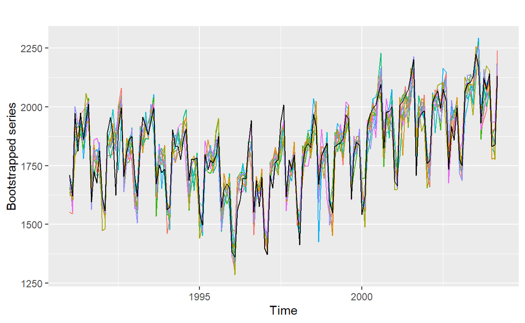

```
set.seed(10)
bootseries <- bld.mbb.bootstrap(ridership.ts,10) %>% as.data.frame() %>% ts(start=1991, freq=12)
autoplot(ridership.ts, ylab="Bootstrapped series") + autolayer(bootseries, colour=TRUE) +
autolayer(ridership.ts, colour=FALSE)  + guides(colour="none")
```

- 붓스트랩의 가장 큰 핵심은 예측구간을 만들 수 있다는 것과 bagging을 이용하여 점 예측을 향상시킬 수 있다는 것이다.

# **붓스트랩 시계열로부터 예측구간**

- 시계열 모형에서 얻는 거의 모든 예측구간은 너무 좁으며 이는 불확실성의 모든 원인을 고려하지 않았기 때문에 생기는 현상이다.
- 시계열 모형들에 대한 예측구간을 생성할 때, 적어도 4가지를 고려해야한다.
  - 무작위 오차항
  - 모수 추정
  - 과거 데이터에 대한 모형 선택
  - 과거 데이터의 연장선 상에서 미래 것을 생성하는 과정
- 일반적으로 무작위 오차항만을 고려한다.
- 붓스트랩 방법을 이용하면 위의 4가지를 고려하는 예측구간을 구할 수 있다.
- 다음은 `simultate()` 함수를 이용하여 예측구간을 생성하는 방법이다.

```
set.seed(10)
nsim   <- 1000L
sim    <- bld.mbb.bootstrap(ridership.ts,nsim)

h      <- 36L
future <- sapply(sim, function(x) simulate(ets(x), nsim=h, seed=100)) # Ets() => Return ets model/ Simulate(fitted model, nsim,seed ) => Simulate nsim from the distribution corresponding to a fitted model
future <- t(future)
```

- 붓스트랩 시계열을 ETS 모형으로 변환한 후 ETS 모형으로부터 36개를 시뮬레이션한다.
- 이렇게 시뮬레이션된 표본의 분위수와 평균을 이용하여 예측구간과 점 예측을 할 수 있다.

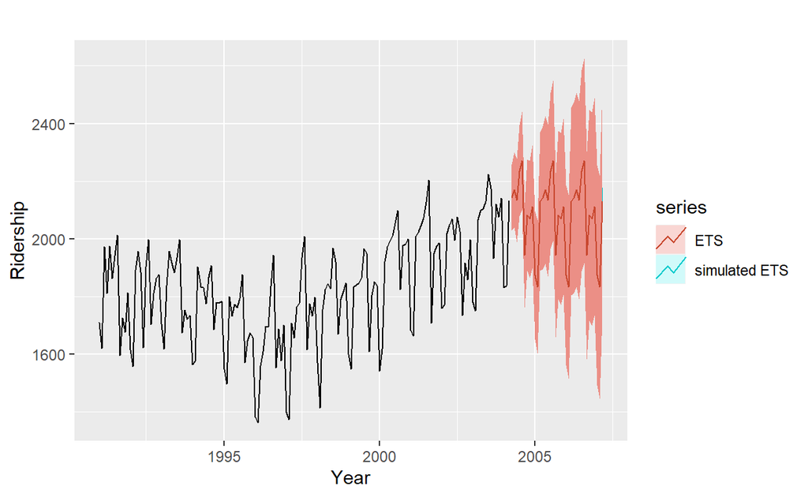

```
start  <- tsp(ridership.ts)[2]+1/12 # Tsp(time series)[2] : End / +1/12 : Forecast
simfc  <- structure(list(

       mean = ts(colMeans(future), start=start, frequency = 12),
      lower = ts(apply(future, 2, quantile, prob=0.025), start = start, frequency = 12),
      upper = ts(apply(future, 2, quantile, prob=0.975), start = start, frequency = 12),
      level = 95),
      class= "forecast"
      )


etsfc <- forecast(ets(ridership.ts), h=h, level=95)
autoplot(ridership.ts) + xlab("Year") + ylab("Ridership") +
autolayer(simfc, series="simulated ETS") +
autolayer(etsfc, series="ETS")
```

- 시뮬레이션으로 얻어진 예측구간은 원래 data를 직접 ETS 모형으로 적용하여 얻어진 것보다 클 수 있다.

# **ETS 모형으로부터 예측**

- 붓스트랩 시계열에 대한 장점은 예측 정확도를 향상시키는 것이다.
- 예측구간을 향상시키는 것보다 점 예측 정확도를 향상시키는 것에 관심이 있다면 붓스트랩 시계열의 평균을 이용하여 빠르게 얻을 수 있다.
- 다음은 붓스트랩 시계열에 대하여 점 예측을 생성하는 방법이다.

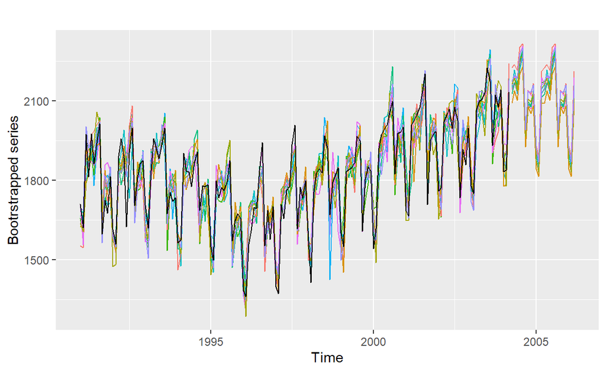

```
set.seed(10)
sim <- bld.mbb.bootstrap(ridership.ts,10) %>% as.data.frame() %>% ts(frequency = 12, start=1991)

fc  <- lapply(sim, function(x){ forecast(ets(x))[["mean"]]})%>% as.data.frame() %>% ts(frequency = 12, start=start)

autoplot(ridership.ts) + autolayer(sim, colour=TRUE) +
autolayer(fc, colour=TRUE) +
autolayer(ridership.ts, colour=FALSE) +
ylab("Bootrstrapped series") + guides(colour="none")
```

- 각각의 붓스트랩 시계열을 ETS 모형으로 변환한 후 `forecast()` 함수를 이용하여 점 예측값을 얻었다.
- 총 붓스트랩한 갯수만큼 결과가 나온다.
- 이러한 예측값들의 평균은 원래 data의 the bagged forecasts를 준다.

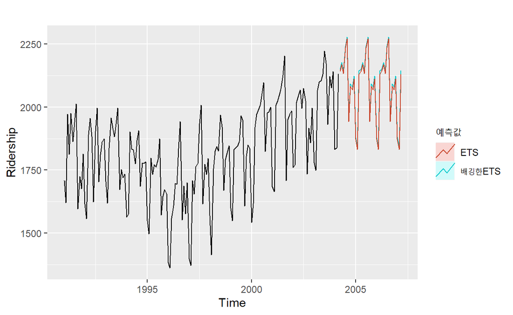

[output not shown]

- etsfc는 원 시계열을 ETS모형으로 직접 변환한 후 예측을 실시하였다.
- baggedfc는 원 시계열로부터 block bootstrap을 이용하여 1000세트를 생성한 후 ETS 모형으로 변환하여 예측을 실시하였다.
  - `baggedETS(y, bootstrapped_series=bld.mbb.bootstrap(y, 100),..)` 함수는 붓스트랩 시계열을 100세트 생성 후 ETS 모형으로 변환한다.
  - `forecast` 함수를 이용하여 각각의 ETS 모형에 대하여 예측한 점 예측 결과값들의 평균을 구하는 bagging 방법을 이용하였다.

```
baggedfc
```

```
         Point Forecast   Lo 100   Hi 100
Apr 2004       2150.164 1988.682 2263.414
May 2004       2177.151 2024.557 2275.871
Jun 2004       2140.064 1973.532 2259.436
Jul 2004       2241.455 2105.642 2358.373
Aug 2004       2278.213 2140.330 2398.545
Sep 2004       1950.673 1816.863 2071.491
Oct 2004       2093.102 1963.086 2203.492
Nov 2004       2079.605 1925.048 2224.486
Dec 2004       2122.788 1979.585 2293.907
Jan 2005       1879.856 1749.708 2053.186
Feb 2005       1844.998 1714.962 1983.270
Mar 2005       2144.299 2009.481 2295.531
Apr 2005       2150.265 1988.682 2297.538
May 2005       2177.251 2024.557 2352.798
Jun 2005       2140.164 1973.532 2318.716
Jul 2005       2241.556 2105.642 2425.708
Aug 2005       2278.313 2140.330 2475.756
Sep 2005       1950.769 1816.863 2148.702
Oct 2005       2093.199 1963.086 2270.399
Nov 2005       2079.702 1925.048 2301.697
Dec 2005       2122.885 1979.585 2371.118
Jan 2006       1879.950 1749.708 2130.397
Feb 2006       1845.092 1714.962 2060.480
Mar 2006       2144.395 2009.481 2372.742
Apr 2006       2150.361 1988.682 2374.748
May 2006       2177.347 2024.557 2430.009
Jun 2006       2140.259 1973.532 2395.927
Jul 2006       2241.651 2105.642 2502.919
Aug 2006       2278.409 2140.330 2552.967
Sep 2006       1950.861 1816.863 2225.913
Oct 2006       2093.292 1963.086 2347.610
Nov 2006       2079.795 1925.048 2378.908
Dec 2006       2122.977 1979.585 2448.328
Jan 2007       1880.041 1749.708 2207.608
Feb 2007       1845.182 1714.962 2137.691
Mar 2007       2144.487 2009.481 2449.953
```

- 기본적으로 Point Forecast, Lo 100, Hi 100이 나오며 lower 값은 최솟값, upper 값은 최댓값이다.
- Point Forecast는 각 붓스트랩 ETS 모형의 점 예측값들의 평균이다.

```
baggedfc$mean
```

```
          Jan      Feb      Mar      Apr      May      Jun      Jul
2004                            2150.164 2177.151 2140.064 2241.455
2005 1879.856 1844.998 2144.299 2150.265 2177.251 2140.164 2241.556
2006 1879.950 1845.092 2144.395 2150.361 2177.347 2140.259 2241.651
2007 1880.041 1845.182 2144.487
          Aug      Sep      Oct      Nov      Dec
2004 2278.213 1950.673 2093.102 2079.605 2122.788
2005 2278.313 1950.769 2093.199 2079.702 2122.885
2006 2278.409 1950.861 2093.292 2079.795 2122.977
2007
```

- Point Forecast와 같은 것을 볼 수 있다.

```
baggedfc$median
```

```
          Jan      Feb      Mar      Apr      May      Jun      Jul
2004                            2151.924 2179.017 2141.878 2243.229
2005 1882.068 1847.659 2146.491 2151.924 2179.017 2141.878 2243.229
2006 1882.068 1847.659 2146.491 2151.924 2179.017 2141.878 2243.229
2007 1882.068 1847.659 2146.491
          Aug      Sep      Oct      Nov      Dec
2004 2279.652 1951.307 2095.773 2081.595 2124.485
2005 2279.652 1951.307 2095.773 2081.595 2124.519
2006 2279.652 1951.307 2095.773 2081.595 2124.519
2007
```

- 각 붓스트랩 ETS 모형의 점 예측값들의 중앙값도 볼 수 있다.

```
baggedfc$forecasts_boot
```

```
          [,1]     [,2]     [,3]     [,4]     [,5]     [,6]     [,7]
 [1,] 2142.450 2161.326 2148.912 2174.982 2225.378 2124.695 2162.297
 [2,] 2169.729 2187.475 2216.862 2181.658 2236.035 2166.450 2190.892
 [3,] 2133.398 2127.670 2153.269 2159.425 2214.734 2152.281 2186.112
 [4,] 2235.669 2247.255 2220.859 2248.726 2302.764 2256.118 2274.234
 [5,] 2271.197 2279.002 2266.269 2283.445 2315.444 2289.533 2305.256
 [6,] 1942.390 1934.100 1957.333 1935.731 1982.811 1974.886 1971.033
 [7,] 2082.277 2087.135 2089.734 2067.868 2140.202 2095.551 2138.460
 [8,] 2068.615 2078.455 2076.419 2084.450 2125.250 2083.118 2121.749
 [9,] 2111.583 2131.894 2137.622 2126.288 2164.720 2125.493 2115.026
[10,] 1872.771 1896.870 1893.596 1897.115 1927.159 1904.289 1901.673
[11,] 1832.721 1850.312 1854.339 1884.063 1889.707 1872.473 1890.293
[12,] 2129.702 2142.909 2127.442 2166.590 2210.078 2114.808 2187.295
[13,] 2142.450 2161.326 2148.912 2174.982 2225.378 2124.695 2162.297
[14,] 2169.729 2187.475 2216.862 2181.658 2236.035 2166.450 2190.892
```

[output cut: 5276 more lines]

- 각 붓스트랩 ETS 모형에 대하여 예측을 실시한 점 예측 결과값이다.
- 즉, 붓스트랩한 모형 갯수 만큼 나오는 것이고, 이것들의 평균, 중앙값 등을 통해서 하나의 예측값을 계산한다.

# **ARIMA 모형으로부터 예측**

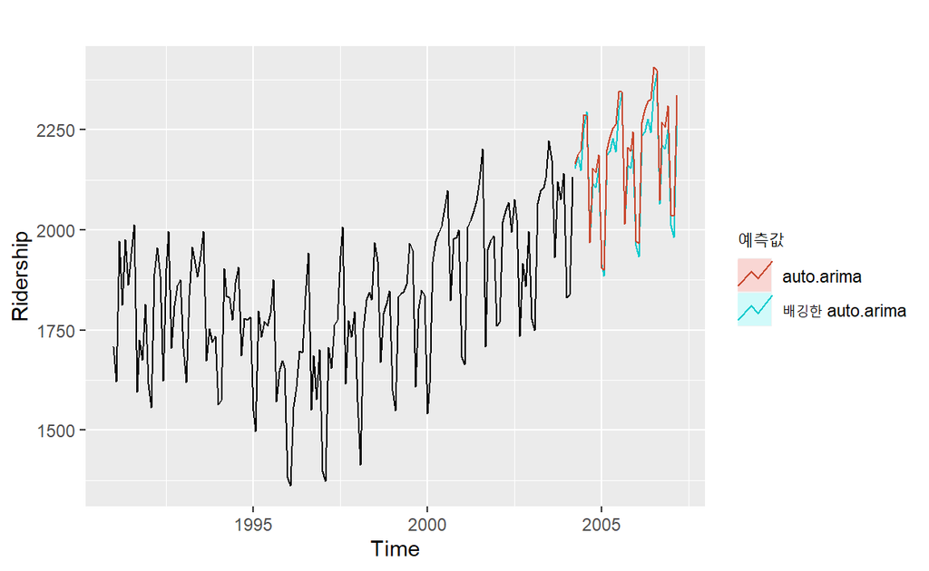

[output not shown]

```
baggedfc
```

```
         Point Forecast   Lo 100   Hi 100
Apr 2004       2153.882 1937.294 2266.685
May 2004       2183.636 2069.629 2285.067
Jun 2004       2148.389 2013.086 2272.431
Jul 2004       2253.708 2091.587 2395.766
Aug 2004       2294.468 2119.322 2436.396
Sep 2004       1970.476 1800.117 2120.375
Oct 2004       2115.897 1984.738 2241.010
Nov 2004       2106.329 1973.407 2213.324
Dec 2004       2154.448 1981.587 2281.573
Jan 2005       1915.192 1776.119 2043.255
Feb 2005       1884.586 1730.378 2030.399
Mar 2005       2188.100 2014.402 2310.890
Apr 2005       2197.165 2020.890 2381.263
May 2005       2228.438 2095.065 2406.012
Jun 2005       2194.269 2053.861 2391.764
Jul 2005       2299.863 2113.823 2490.838
Aug 2005       2340.941 2146.282 2538.180
Sep 2005       2016.469 1857.274 2227.402
Oct 2005       2162.298 1982.864 2370.492
Nov 2005       2153.054 2009.254 2335.063
Dec 2005       2200.961 2010.381 2417.223
Jan 2006       1961.808 1786.275 2172.388
Feb 2006       1932.164 1766.587 2154.232
Mar 2006       2235.709 2044.794 2427.130
Apr 2006       2245.106 2042.922 2489.122
May 2006       2277.074 2101.503 2530.184
Jun 2006       2242.617 2082.520 2505.917
Jul 2006       2348.511 2139.333 2630.956
Aug 2006       2389.409 2210.643 2679.100
Sep 2006       2065.152 1885.333 2348.239
Oct 2006       2210.764 2040.031 2506.740
Nov 2006       2201.499 2042.913 2474.923
Dec 2006       2249.740 2091.811 2548.098
Jan 2007       2010.635 1853.417 2293.973
Feb 2007       1980.775 1797.700 2261.874
Mar 2007       2284.621 2067.422 2553.645
```

```
baggedfc$mean
```

```
          Jan      Feb      Mar      Apr      May      Jun      Jul
2004                            2153.882 2183.636 2148.389 2253.708
2005 1915.192 1884.586 2188.100 2197.165 2228.438 2194.269 2299.863
2006 1961.808 1932.164 2235.709 2245.106 2277.074 2242.617 2348.511
2007 2010.635 1980.775 2284.621
          Aug      Sep      Oct      Nov      Dec
2004 2294.468 1970.476 2115.897 2106.329 2154.448
2005 2340.941 2016.469 2162.298 2153.054 2200.961
2006 2389.409 2065.152 2210.764 2201.499 2249.740
2007
```

```
baggedfc$median
```

```
          Jan      Feb      Mar      Apr      May      Jun      Jul
2004                            2156.571 2184.457 2148.574 2254.712
2005 1913.516 1885.430 2189.043 2195.443 2225.660 2191.746 2297.086
2006 1956.592 1928.277 2231.206 2238.849 2271.053 2235.370 2341.356
2007 2001.732 1971.359 2276.520
          Aug      Sep      Oct      Nov      Dec
2004 2294.282 1968.389 2116.077 2106.923 2153.312
2005 2337.567 2011.627 2159.640 2149.745 2195.802
2006 2383.589 2056.325 2205.160 2193.248 2241.352
2007
```

```
# 95% confidence interval

boot.pred <- t(baggedfc$forecasts_boot)
CI.pred   <- apply(boot.pred, 2, function(x) { quantile(x, probs = c(0.025, 0.975) ) })
HPD.pred  <- apply(boot.pred, 2, function(x) { HPDinterval(mcmc(x)) })
```

- 신뢰구간은 따로 붓스트랩 시계열의 각 점 예측값들을 이용하여 구해야한다. 기본적으로 나오는 건 100% 신뢰구간으로 최솟값과 최댓값이 나온다.

```
data.frame("upper"=baggedfc$upper, "lower"=baggedfc$lower, "length of interval"=baggedfc$upper-baggedfc$lower)   # The upper and lower of  forecast interval is max and min. Not prediction interval.
```

```
      upper    lower length.of.interval
1  2266.685 1937.294           329.3910
2  2285.067 2069.629           215.4375
3  2272.431 2013.086           259.3447
4  2395.766 2091.587           304.1784
5  2436.396 2119.322           317.0741
6  2120.375 1800.117           320.2573
7  2241.010 1984.738           256.2721
8  2213.324 1973.407           239.9170
9  2281.573 1981.587           299.9859
10 2043.255 1776.119           267.1350
11 2030.399 1730.378           300.0212
12 2310.890 2014.402           296.4881
13 2381.263 2020.890           360.3728
14 2406.012 2095.065           310.9464
```

[output cut: 22 more lines]

```
data.frame("CI.upper"=CI.pred[2,], "CI.lower"=CI.pred[1,], "length of CI"=CI.pred[2,]-CI.pred[1,])
```

```
   CI.upper CI.lower length.of.CI
1  2224.872 2076.673     148.1994
2  2251.697 2107.875     143.8219
3  2220.036 2070.253     149.7833
4  2326.578 2178.223     148.3554
5  2366.523 2223.242     143.2802
6  2046.135 1902.948     143.1872
7  2186.087 2045.926     140.1609
8  2182.065 2037.011     145.0541
9  2223.321 2081.973     141.3478
10 1991.284 1841.539     149.7455
11 1961.782 1812.384     149.3975
12 2275.095 2103.829     171.2656
13 2293.754 2105.318     188.4356
14 2328.965 2146.466     182.4986
```

[output cut: 22 more lines]

```
data.frame("HPD.upper"=HPD.pred[2,], "HPD.lower"=HPD.pred[1,], "length of HPD"=HPD.pred[2,]-HPD.pred[1,])
```

```
   HPD.upper HPD.lower length.of.HPD
1   2228.822  2082.626      146.1954
2   2250.579  2107.149      143.4298
3   2224.127  2075.720      148.4068
4   2330.521  2185.375      145.1458
5   2366.486  2223.223      143.2633
6   2039.410  1897.519      141.8913
7   2184.358  2044.634      139.7232
8   2185.123  2044.021      141.1018
9   2226.671  2086.480      140.1911
10  1986.129  1836.998      149.1304
11  1963.115  1813.825      149.2902
12  2259.052  2092.391      166.6610
13  2283.626  2101.774      181.8524
14  2329.222  2146.482      182.7400
```

[output cut: 22 more lines]